# EORTC HNSCC Honore et al_07232024 Final Analysis

library(swimplot) library(grid) library(gtable) library(readr) library(mosaic) library(dplyr) library(survival) library(survminer) library(ggplot2) library(scales) library(coxphf) library(ggthemes) library(tidyverse) library(gtsummary) library(flextable) library(parameters) library(car) library(ComplexHeatmap) library(tidyverse) library(readxl) library(janitor) library(DT) library(rms)

#ctDNA Detection Rates by Window and Stages

```r
#ctDNA at Baseline
rm(list=ls())
setwd("~/Downloads")
circ_data <- read.csv("OP-16933_HNSCC Clinical data.csv")
circ_data <- circ_data[circ_data$ctDNA.available=="TRUE",]
circ_data <- circ_data[circ_data$ctDNA.Base!="",]
circ_data$ctDNA.Base <- factor(circ_data$ctDNA.Base, levels=c("NEGATIVE","POSITIVE"))
circ_data <- subset(circ_data, ctDNA.Base %in% c("NEGATIVE", "POSITIVE"))
circ_data$Stage <- factor(circ_data$Stage, levels=c("III","IVA","IVB"))
positive_counts_by_stage <- aggregate(circ_data$ctDNA.Base == "POSITIVE", by=list(circ_data$Stage), FUN=sum)
total_counts_by_stage <- aggregate(circ_data$ctDNA.Base, by=list(circ_data$Stage), FUN=length)
combined_data <- data.frame(
  Stage = total_counts_by_stage$Group.1,
  Total_Count = total_counts_by_stage$x,
  Positive_Count = positive_counts_by_stage$x,
  Rate = (positive_counts_by_stage$x / total_counts_by_stage$x) * 100  # Convert to percentage
)
combined_data$Rate <- sprintf("%.2f%%", combined_data$Rate)
overall_total_count <- nrow(circ_data)
overall_positive_count <- nrow(circ_data[circ_data$ctDNA.Base == "POSITIVE",])
overall_positivity_rate <- (overall_positive_count / overall_total_count) * 100  # Convert to percentage
overall_row <- data.frame(
  Stage = "Overall",
  Total_Count = overall_total_count,
  Positive_Count = overall_positive_count,
  Rate = sprintf("%.2f%%", overall_positivity_rate)
)
combined_data <- rbind(combined_data, overall_row)
print(combined_data)
```

| Stage | Total_Count | Positive_Count | Rate |
| --- | --- | --- | --- |
| III | 16 | 16 | 100.00% |
| IVA | 20 | 20 | 100.00% |
| IVB | 6 | 5 | 83.33% |
| Overall | 42 | 41 | 97.62% |

```r
#ctDNA post-treatment
rm(list=ls())
setwd("~/Downloads")
circ_data <- read.csv("OP-16933_HNSCC Clinical data.csv")
circ_data <- circ_data[circ_data$ctDNA.available=="TRUE",]
circ_data <- circ_data[circ_data$ctDNA.postTx!="",]
circ_data$ctDNA.postTx <- factor(circ_data$ctDNA.postTx, levels=c("NEGATIVE","POSITIVE"))
circ_data$Stage <- factor(circ_data$Stage, levels=c("III","IVA","IVB"))
positive_counts_by_stage <- aggregate(circ_data$ctDNA.postTx == "POSITIVE", by=list(circ_data$Stage), FUN=sum)
total_counts_by_stage <- aggregate(circ_data$ctDNA.postTx, by=list(circ_data$Stage), FUN=length)
combined_data <- data.frame(
  Stage = total_counts_by_stage$Group.1,
  Total_Count = total_counts_by_stage$x,
  Positive_Count = positive_counts_by_stage$x,
  Rate = (positive_counts_by_stage$x / total_counts_by_stage$x) * 100  # Convert to percentage
)
combined_data$Rate <- sprintf("%.2f%%", combined_data$Rate)
overall_total_count <- nrow(circ_data)
overall_positive_count <- nrow(circ_data[circ_data$ctDNA.postTx == "POSITIVE",])
overall_positivity_rate <- (overall_positive_count / overall_total_count) * 100  # Convert to percentage
overall_row <- data.frame(
  Stage = "Overall",
  Total_Count = overall_total_count,
  Positive_Count = overall_positive_count,
  Rate = sprintf("%.2f%%", overall_positivity_rate)
)
combined_data <- rbind(combined_data, overall_row)
print(combined_data)
```

| Stage | Total_Count | Positive_Count | Rate |
| --- | --- | --- | --- |
| III | 15 | 2 | 13.33% |
| IVA | 21 | 0 | 0.00% |
| IVB | 6 | 2 | 33.33% |
| Overall | 42 | 4 | 9.52% |

#Summary Table

```r
rm(list=ls())
setwd("~/Downloads")
circ_data <- read.csv("OP-16933_HNSCC Clinical data.csv")
circ_data <- circ_data[circ_data$ctDNA.available=="TRUE",]

circ_data_subset <- circ_data %>%
  select(
    Gender,
    Age,
    Smoking.Assumption,
    Alcohol.Assumption,
    Prim.Location,
    ECOG,
    Stage,
    Stage.TNM,
    p16,
    NAC,
    Treatment.Type,
    RFS.Event,
    OS.Event,
    FU.Biopsy.months) %>%
  mutate(
    Gender = factor(Gender),
    Age = as.numeric(Age),
    Smoking.Assumption = factor(Smoking.Assumption),
    Alcohol.Assumption = factor(Alcohol.Assumption),
    Prim.Location = factor(Prim.Location),
    ECOG = factor(ECOG),
    Stage = factor(Stage),
    Stage.TNM = factor(Stage.TNM),
    p16 = factor(p16),
    NAC = factor(NAC, levels = c("FALSE", "TRUE"), labels = c("No treatment", "Neoadjuvant Treatment")),
    Treatment.Type = factor(Treatment.Type),
    RFS.Event = factor(RFS.Event, levels = c("FALSE", "TRUE"), labels = c("No Recurrence", "Recurrence")),
    OS.Event = factor(OS.Event, levels = c("FALSE", "TRUE"), labels = c("Alive", "Deceased")),
    FU.Biopsy.months = as.numeric(FU.Biopsy.months))
table1 <- circ_data_subset %>%
  tbl_summary(
    statistic = list(
      all_continuous() ~ "{median} ({min} - {max})",
      all_categorical() ~ "{n} ({p}%)")) %>%
  bold_labels()
table1
```

| **Characteristic** | **N = 43**<sup>1</sup> |
| --- | --- |
| Gender |  |
| Female | 10 (23%) |
| Male | 33 (77%) |
| Age | 67 (28 - 102) |
| Smoking.Assumption | 35 (81%) |
| Alcohol.Assumption | 27 (63%) |
| Prim.Location |  |
| Hypopharynx | 5 (12%) |
| Larynx | 6 (14%) |
| Oral cavity | 5 (12%) |
| Oropharynx | 27 (63%) |
| ECOG |  |
| 0 | 27 (63%) |
| 1 | 14 (33%) |
| 2 | 2 (4.7%) |
| Stage |  |
| III | 16 (37%) |
| IVA | 21 (49%) |
| IVB | 6 (14%) |
| Stage.TNM |  |
| T1-T3N1M0 | 12 (28%) |
| T1-T4N2M0 | 13 (30%) |
| T1-T4N3M0 | 6 (14%) |
| T3N0M0 | 4 (9.3%) |
| T4aN0-N1M0 | 8 (19%) |
| p16 |  |
| Negative | 26 (60%) |
| Positive | 17 (40%) |
| NAC |  |
| No treatment | 37 (86%) |
| Neoadjuvant Treatment | 6 (14%) |
| Treatment.Type |  |
| Chemotherapy | 1 (2.3%) |
| Radiochemotherapy | 29 (67%) |
| Radiochemotherapy, Surgery | 5 (12%) |
| Radioimmunotherapy | 2 (4.7%) |
| Radiotherapy | 3 (7.0%) |
| Radiotherapy, Surgery | 2 (4.7%) |
| Surgery | 1 (2.3%) |
| RFS.Event |  |
| No Recurrence | 32 (74%) |
| Recurrence | 11 (26%) |
| OS.Event |  |
| Alive | 33 (77%) |
| Deceased | 10 (23%) |
| FU.Biopsy.months | 20 (4 - 45) |

<sup>1</sup> n (%); Median (Range)

```r
fit1 <- as_flex_table(
  table1,
  include = everything(),
  return_calls = FALSE,
  strip_md_bold = TRUE)
fit1
```

| Characteristic | N = 431 |
| --- | --- |
| Gender |  |
| Female | 10 (23%) |
| Male | 33 (77%) |
| Age | 67 (28 - 102) |
| Smoking.Assumption | 35 (81%) |
| Alcohol.Assumption | 27 (63%) |
| Prim.Location |  |
| Hypopharynx | 5 (12%) |
| Larynx | 6 (14%) |
| Oral cavity | 5 (12%) |
| Oropharynx | 27 (63%) |
| ECOG |  |
| 0 | 27 (63%) |
| 1 | 14 (33%) |
| 2 | 2 (4.7%) |
| Stage |  |
| III | 16 (37%) |
| IVA | 21 (49%) |
| IVB | 6 (14%) |
| Stage.TNM |  |
| T1-T3N1M0 | 12 (28%) |
| T1-T4N2M0 | 13 (30%) |
| T1-T4N3M0 | 6 (14%) |
| T3N0M0 | 4 (9.3%) |
| T4aN0-N1M0 | 8 (19%) |
| p16 |  |
| Negative | 26 (60%) |
| Positive | 17 (40%) |
| NAC |  |
| No treatment | 37 (86%) |
| Neoadjuvant Treatment | 6 (14%) |
| Treatment.Type |  |
| Chemotherapy | 1 (2.3%) |
| Radiochemotherapy | 29 (67%) |
| Radiochemotherapy, Surgery | 5 (12%) |
| Radioimmunotherapy | 2 (4.7%) |
| Radiotherapy | 3 (7.0%) |
| Radiotherapy, Surgery | 2 (4.7%) |
| Surgery | 1 (2.3%) |
| RFS.Event |  |
| No Recurrence | 32 (74%) |
| Recurrence | 11 (26%) |
| OS.Event |  |
| Alive | 33 (77%) |
| Deceased | 10 (23%) |
| FU.Biopsy.months | 20 (4 - 45) |

1n (%); Median (Range)

```r
save_as_docx(fit1, path= "~/Downloads/table1.docx")
```

#Heatmap for the clinical factors

```r
rm(list=ls())
setwd("~/Downloads")
circ_data <- read.csv("OP-16933_HNSCC Clinical data.csv")
circ_data <- circ_data[circ_data$ctDNA.available=="TRUE",]
circ_data <- circ_data %>% arrange(Stage)
circ_datadf <- as.data.frame(circ_data)

ha <- HeatmapAnnotation(
  Stage = circ_data$Stage,
  Gender = circ_data$Gender,
  Prim.Location = circ_data$Prim.Location,
  p16 = circ_data$p16,
  NAC = circ_data$NAC,
  ctDNA.Base = circ_data$ctDNA.Base,
  ctDNA.postTx = circ_data$ctDNA.postTx,
  RFS.Event = circ_data$RFS.Event,
  OS.Event = circ_data$OS.Event,

    col = list(Stage = c("III" = "seagreen1", "IVA" = "khaki", "IVB" = "orange"),
    Gender = c("Female" = "goldenrod" , "Male" = "blue4"),
    Prim.Location = c("Hypopharynx" = "purple", "Oropharynx" ="lightblue", "Larynx" = "brown2", "Oral cavity" = "lightgrey"),
    p16 = c("Negative" = "yellow", "Positive" ="brown"),
    NAC = c("TRUE" = "darkmagenta", "FALSE" = "grey"),
    ctDNA.Base = c("POSITIVE" = "red3", "NEGATIVE" ="blue"),
    ctDNA.postTx = c("POSITIVE" = "red3", "NEGATIVE" ="blue"),
    RFS.Event = c("TRUE" = "red3", "FALSE" ="blue"),
    OS.Event = c("TRUE" = "black", "FALSE" ="grey")
)
)
ht <- Heatmap(matrix(nrow = 0, ncol = length(circ_data$Stage)),show_row_names = FALSE,cluster_rows = F,cluster_columns = FALSE, top_annotation = ha)
pdf("heatmap.pdf",width = 7, height = 7)
draw(ht, annotation_legend_side = "bottom")
dev.off()
```

#Overview plot

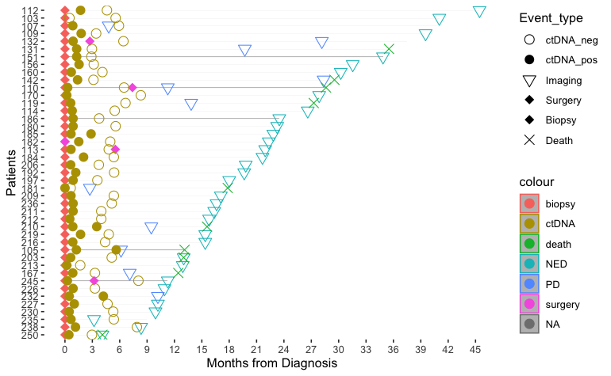

```r
setwd("~/Downloads")
clinstage <- read.csv("OP-16933_ HNSCC OP.csv")
clinstage_df <- as.data.frame(clinstage)

# Creating the basic swimmer plot
oplot <- swimmer_plot(df=clinstage_df,
                      id='PatientName',
                      end='fu.diff.months',
                      fill='gray',
                      width=.01)

# Adding themes and scales
oplot <- oplot + theme(panel.border = element_blank())
oplot <- oplot + scale_y_continuous(breaks = seq(0, 48, by = 3))
oplot <- oplot + labs(x ="Patients", y="Months from Diagnosis")

# Adding swimmer points
oplot_ev1 <- oplot + swimmer_points(df_points=clinstage_df,
                                    id='PatientName',
                                    time='date.diff.months',
                                    name_shape ='Event_type',
                                    name_col = 'Event',
                                    size=3.5,fill='black')
# Optionally uncomment and use col='darkgreen' if needed

# Adding shape manual scale
oplot_ev1.1 <- oplot_ev1 + ggplot2::scale_shape_manual(name="Event_type",
                                                       values=c(1,16,6,18,18,4),
                                                       breaks=c('ctDNA_neg','ctDNA_pos', 'Imaging','Surgery','Biopsy', 'Death'))

# Display the plot
oplot_ev1.1
```

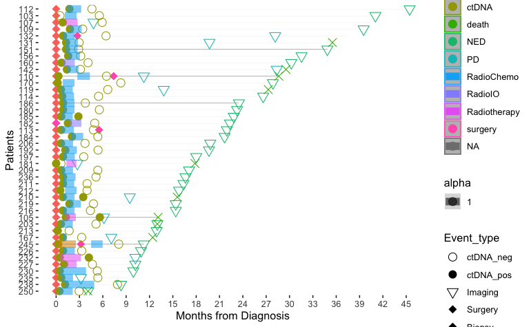

```r
                                    oplot_ev2 <- oplot_ev1.1 + swimmer_lines(df_lines=clinstage_df,
                                                                             id='PatientName',
                                                                             start='Tx_start.months',
                                                                             end='Tx_end.months',
                                                                             name_col='Tx_type',
                                                                             size=3.5,
                                                                             name_alpha = 1.0)
                                    oplot_ev2 <- oplot_ev2 + guides(linetype = guide_legend(override.aes = list(size = 5, color = "black")))
                                    oplot_ev2
```

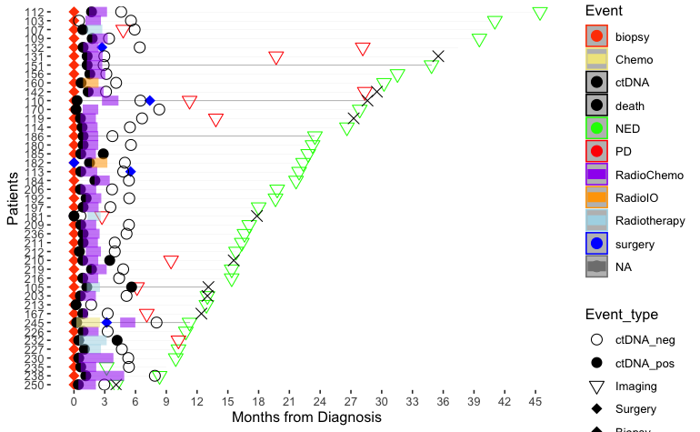

```r
                                    oplot_ev2.2 <- oplot_ev2 + ggplot2::scale_color_manual(name="Event",values=c( "orangered", "khaki", "black", "black", "green", "red", "purple", "orange", "lightblue", "blue"))
                                    oplot_ev2.2
```

#RFS in Complete Cohort (N=50)

```r
rm(list=ls())
setwd("~/Downloads")
circ_data <- read.csv("OP-16933_HNSCC Clinical data.csv")
circ_datadf <- as.data.frame(circ_data)

survfit(Surv(time = circ_data$RFS.months, event = circ_data$RFS.Event)~HNSCC.Cohort, data = circ_data)
```

```
Call: survfit(formula = Surv(time = circ_data$RFS.months, event = circ_data$RFS.Event) ~
    HNSCC.Cohort, data = circ_data)

      n events median 0.95LCL 0.95UCL
[1,] 50     13     NA    25.5      NA
```

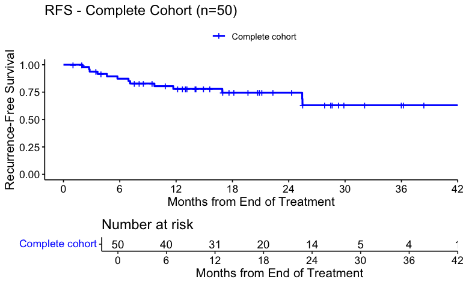

```r
surv_object <-Surv(time = circ_data$RFS.months, event = circ_data$RFS.Event)
KM_curve <- survfit(surv_object ~ HNSCC.Cohort, data = circ_data,conf.int=0.95,conf.type="log-log")
ggsurvplot(KM_curve, data = circ_data, pval = FALSE, conf.int = FALSE, risk.table = TRUE, break.time.by=6, palette=c("blue"), title="RFS - Complete Cohort (n=50)", ylab= "Recurrence-Free Survival", xlab="Months from End of Treatment", legend.labs=c("Complete cohort"), legend.title="")
```

```r
summary(KM_curve, times= c(18, 24, 36))
```

```
Call: survfit(formula = surv_object ~ HNSCC.Cohort, data = circ_data,
    conf.int = 0.95, conf.type = "log-log")

 time n.risk n.event survival std.err lower 95% CI upper 95% CI
   18     20      11    0.746  0.0679        0.583        0.852
   24     14       0    0.746  0.0679        0.583        0.852
   36      4       2    0.631  0.0942        0.419        0.783
```

#OS in Complete Cohort (N=50)

```r
rm(list=ls())
setwd("~/Downloads")
circ_data <- read.csv("OP-16933_HNSCC Clinical data.csv")
circ_datadf <- as.data.frame(circ_data)

survfit(Surv(time = circ_data$FU.Biopsy.months, event = circ_data$OS.Event)~HNSCC.Cohort, data = circ_data)
```

```
Call: survfit(formula = Surv(time = circ_data$FU.Biopsy.months, event = circ_data$OS.Event) ~
    HNSCC.Cohort, data = circ_data)

      n events median 0.95LCL 0.95UCL
[1,] 50     12     NA    29.5      NA
```

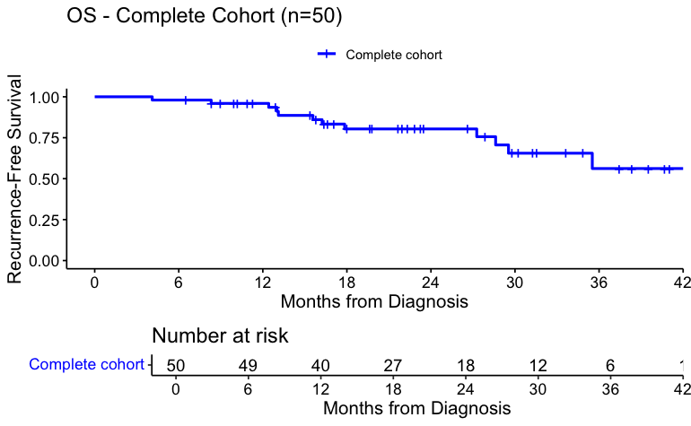

```r
surv_object <-Surv(time = circ_data$FU.Biopsy.months, event = circ_data$OS.Event)
KM_curve <- survfit(surv_object ~ HNSCC.Cohort, data = circ_data,conf.int=0.95,conf.type="log-log")
ggsurvplot(KM_curve, data = circ_data, pval = FALSE, conf.int = FALSE, risk.table = TRUE, break.time.by=6, palette=c("blue"), title="OS - Complete Cohort (n=50)", ylab= "Recurrence-Free Survival", xlab="Months from Diagnosis", legend.labs=c("Complete cohort"), legend.title="")
```

```r
summary(KM_curve, times= c(18, 24, 36))
```

```
Call: survfit(formula = surv_object ~ HNSCC.Cohort, data = circ_data,
    conf.int = 0.95, conf.type = "log-log")

 time n.risk n.event survival std.err lower 95% CI upper 95% CI
   18     27       8    0.804  0.0632        0.643        0.898
   24     18       0    0.804  0.0632        0.643        0.898
   36      6       4    0.562  0.1177        0.309        0.754
```

#Association of Baseline ctDNA MTM levels with clinicopathological factors

```r
rm(list=ls())
setwd("~/Downloads")
circ_data <- read.csv("OP-16933_HNSCC Clinical data.csv")
circ_data <- circ_data[circ_data$ctDNA.available=="TRUE",]
circ_data <- circ_data[circ_data$ctDNA.Base!="",]
circ_datadf <- as.data.frame(circ_data)

tally(~cStage, data=circ_data, margins = TRUE)
```

```
cStage
  III    IV Total
   16    26    42
```

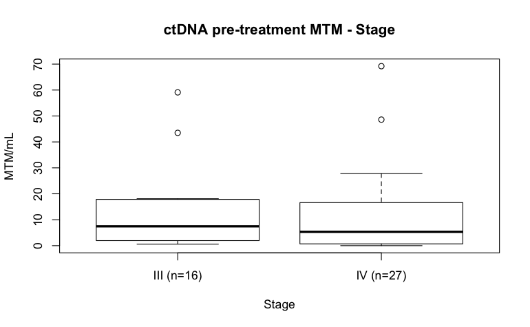

```r
circ_data$cStage <- factor(circ_data$cStage, levels = c("III","IV"), labels = c("III (n=16)","IV (n=27)"))
boxplot(ctDNA.Base.MTM~cStage, data=circ_data, main="ctDNA pre-treatment MTM - Stage", xlab="Stage", ylab="MTM/mL", col="white",border="black")
```

```r
m1<-wilcox.test(ctDNA.Base.MTM ~ cStage, data=circ_data, na.rm=TRUE, exact=FALSE, conf.int=TRUE)
print(m1)
```

```
    Wilcoxon rank sum test with continuity correction

data:  ctDNA.Base.MTM by cStage
W = 228, p-value = 0.6135
alternative hypothesis: true location shift is not equal to 0
95 percent confidence interval:
 -5.400007  6.100017
sample estimates:
difference in location
                1.0637
```

```r
tally(~cT.Status, data=circ_data, margins = TRUE)
```

```
cT.Status
cT1-T2 cT3-T4  Total
    16     26     42
```

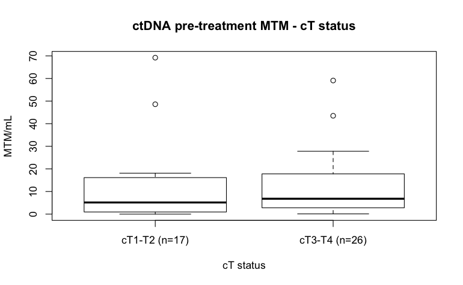

```r
circ_data$cT.Status <- factor(circ_data$cT.Status, levels = c("cT1-T2","cT3-T4"), labels = c("cT1-T2 (n=17)","cT3-T4 (n=26)"))
boxplot(ctDNA.Base.MTM~cT.Status, data=circ_data, main="ctDNA pre-treatment MTM - cT status", xlab="cT status", ylab="MTM/mL", col="white",border="black")
```

```r
m2<-wilcox.test(ctDNA.Base.MTM ~ cT.Status, data=circ_data, na.rm=TRUE, exact=FALSE, conf.int=TRUE)
print(m2)
```

```
    Wilcoxon rank sum test with continuity correction

data:  ctDNA.Base.MTM by cT.Status
W = 179, p-value = 0.4603
alternative hypothesis: true location shift is not equal to 0
95 percent confidence interval:
 -8.499967  3.599946
sample estimates:
difference in location
              -1.59994
```

```r
tally(~cN.Status, data=circ_data, margins = TRUE)
```

```
cN.Status
   cN0 cN1-N3  Total
     8     34     42
```

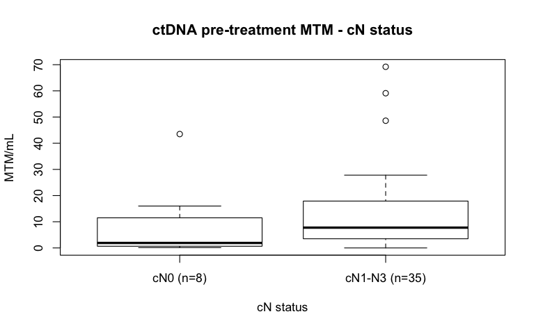

```r
circ_data$cN.Status <- factor(circ_data$cN.Status, levels = c("cN0","cN1-N3"), labels = c("cN0 (n=8)","cN1-N3 (n=35)"))
boxplot(ctDNA.Base.MTM~cN.Status, data=circ_data, main="ctDNA pre-treatment MTM - cN status", xlab="cN status", ylab="MTM/mL", col="white",border="black")
```

```r
m3<-wilcox.test(ctDNA.Base.MTM ~ cN.Status, data=circ_data, na.rm=TRUE, exact=FALSE, conf.int=TRUE)
print(m3)
```

```
    Wilcoxon rank sum test with continuity correction

data:  ctDNA.Base.MTM by cN.Status
W = 93, p-value = 0.1733
alternative hypothesis: true location shift is not equal to 0
95 percent confidence interval:
 -12.900026   1.300003
sample estimates:
difference in location
             -3.227956
```

```r
tally(~p16, data=circ_data, margins = TRUE)
```

```
p16
Negative Positive    Total
      25       17       42
```

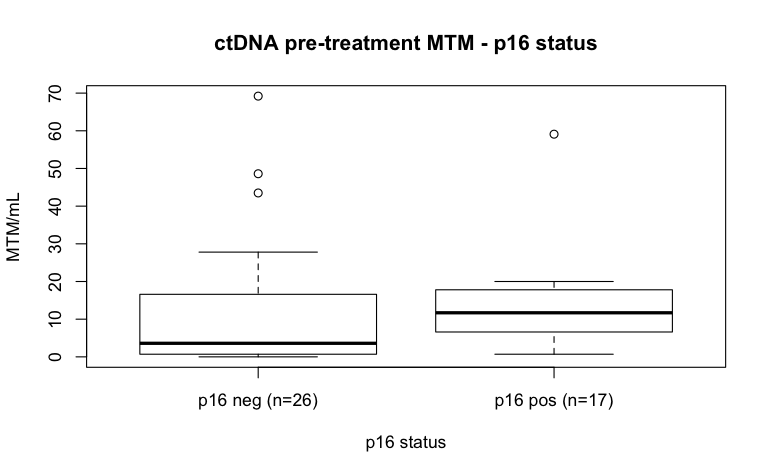

```r
circ_data$p16 <- factor(circ_data$p16, levels = c("Negative","Positive"), labels = c("p16 neg (n=26)","p16 pos (n=17)"))
boxplot(ctDNA.Base.MTM~p16, data=circ_data, main="ctDNA pre-treatment MTM - p16 status", xlab="p16 status", ylab="MTM/mL", col="white",border="black")
```

```r
m4<-wilcox.test(ctDNA.Base.MTM ~ p16, data=circ_data, na.rm=TRUE, exact=FALSE, conf.int=TRUE)
print(m4)
```

```
    Wilcoxon rank sum test with continuity correction

data:  ctDNA.Base.MTM by p16
W = 142.5, p-value = 0.07488
alternative hypothesis: true location shift is not equal to 0
95 percent confidence interval:
 -10.79993   1.59996
sample estimates:
difference in location
             -5.100049
```

```r
tally(~Location, data=circ_data, margins = TRUE)
```

```
Location
         Larynx Oropharynx/Oral           Total
              6              36              42
```

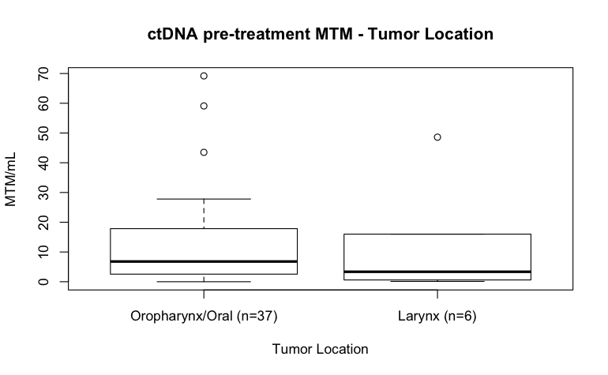

```r
circ_data$Location <- factor(circ_data$Location, levels = c("Oropharynx/Oral","Larynx"), labels = c("Oropharynx/Oral (n=37)","Larynx (n=6)"))
boxplot(ctDNA.Base.MTM~Location, data=circ_data, main="ctDNA pre-treatment MTM - Tumor Location", xlab="Tumor Location", ylab="MTM/mL", col="white",border="black")
```

```r
m4<-wilcox.test(ctDNA.Base.MTM ~ Location, data=circ_data, na.rm=TRUE, exact=FALSE, conf.int=TRUE)
print(m4)
```

```
    Wilcoxon rank sum test with continuity correction

data:  ctDNA.Base.MTM by Location
W = 131, p-value = 0.4186
alternative hypothesis: true location shift is not equal to 0
95 percent confidence interval:
 -7.099978 12.499975
sample estimates:
difference in location
              2.099941
```

#Median MTM/mL levels for ctDNA positive pts post-treatment

```r
rm(list=ls())
setwd("~/Downloads")
circ_data <- read.csv("OP-16933_HNSCC Clinical data.csv")
circ_data <- circ_data[circ_data$ctDNA.available=="TRUE",]
circ_data <- circ_data[circ_data$ctDNA.postTx!="",]
circ_data <- circ_data[circ_data$ctDNA.postTx=="POSITIVE",]

median_ctDNA <- median(circ_data$ctDNA.postTx.MTM, na.rm = TRUE)
range_ctDNA <- range(circ_data$ctDNA.postTx.MTM, na.rm = TRUE)
cat("Median MTM/mL post-treatment:", median_ctDNA, "\n")
```

```
Median MTM/mL post-treatment: 0.95
```

```r
cat("Range MTM/mL post-treatment:", range_ctDNA[1], "-", range_ctDNA[2], "\n")
```

```
Range MTM/mL post-treatment: 0.1 - 5
```

#Median time from end treatment to radiological recurrence for ctDNA negative pts post-treatment

```r
rm(list=ls())
setwd("~/Downloads")
circ_data <- read.csv("OP-16933_HNSCC Clinical data.csv")
circ_data <- circ_data[circ_data$ctDNA.available=="TRUE",]
circ_data <- circ_data[circ_data$ctDNA.postTx!="",]
circ_data <- circ_data[circ_data$ctDNA.postTx=="NEGATIVE",]
circ_data <- circ_data[circ_data$RFS.Event=="TRUE",]

median_RFS <- median(circ_data$RFS.months, na.rm = TRUE)
range_RFS <- range(circ_data$RFS.months, na.rm = TRUE)
cat("Median RFS:", median_RFS, "\n")
```

```
Median RFS: 11.7
```

```r
cat("Range RFS:", range_RFS[1], "-", range_RFS[2], "\n")
```

```
Range RFS: 2.73 - 25.46
```

#RFS by ctDNA post-treatment

```r
rm(list=ls())
setwd("~/Downloads")
circ_data <- read.csv("OP-16933_HNSCC Clinical data.csv")
circ_data <- circ_data[circ_data$ctDNA.available=="TRUE",]
circ_data <- circ_data[circ_data$ctDNA.postTx!="",]
circ_datadf <- as.data.frame(circ_data)

survfit(Surv(time = circ_data$RFS.months, event = circ_data$RFS.Event)~ctDNA.postTx, data = circ_data)
```

```
Call: survfit(formula = Surv(time = circ_data$RFS.months, event = circ_data$RFS.Event) ~
    ctDNA.postTx, data = circ_data)

                       n events median 0.95LCL 0.95UCL
ctDNA.postTx=NEGATIVE 38      7     NA   25.46      NA
ctDNA.postTx=POSITIVE  4      3    8.4    3.61      NA
```

```r
event_summary <- circ_data %>%
  group_by(ctDNA.postTx) %>%
  summarise(
    Total = n(),
    Events = sum(RFS.Event),
    Fraction = Events / n(),
    Percentage = (Events / n()) * 100
  )
print(event_summary)
```

| ctDNA.postTx | Total | Events | Fraction | Percentage |
| --- | --- | --- | --- | --- |
| NEGATIVE | 38 | 7 | 0.1842105 | 18.42105 |
| POSITIVE | 4 | 3 | 0.7500000 | 75.00000 |

```r
surv_object <-Surv(time = circ_data$RFS.months, event = circ_data$RFS.Event)
KM_curve <- survfit(surv_object ~ ctDNA.postTx, data = circ_data,conf.int=0.95,conf.type="log-log")
ggsurvplot(KM_curve, data = circ_data, pval = TRUE, conf.int = FALSE, risk.table = TRUE, break.time.by=6, palette=c("blue","red"), title="RFS - ctDNA post-treatment", ylab= "Recurrence-Free Survival", xlab="Months from End of Treatment", legend.labs=c("ctDNA Negative", "ctDNA Positive"), legend.title="")
summary(KM_curve, times= c(0, 12, 24, 36))
```

[output not shown]

```
Call: survfit(formula = surv_object ~ ctDNA.postTx, data = circ_data,
    conf.int = 0.95, conf.type = "log-log")

                ctDNA.postTx=NEGATIVE
 time n.risk n.event survival std.err lower 95% CI upper 95% CI
    0     38       0    1.000  0.0000        1.000        1.000
   12     26       4    0.881  0.0561        0.712        0.954
   24     10       1    0.832  0.0712        0.633        0.929
   36      3       2    0.647  0.1279        0.346        0.836

                ctDNA.postTx=POSITIVE
 time n.risk n.event survival std.err lower 95% CI upper 95% CI
    0      4       0     1.00   0.000      1.00000        1.000
   12      1       3     0.25   0.217      0.00895        0.665
```

```r
circ_data$ctDNA.postTx <- factor(circ_data$ctDNA.postTx, levels=c("NEGATIVE","POSITIVE"))
cox_fit <- coxph(surv_object ~ ctDNA.postTx, data=circ_data)
ggforest(cox_fit,data = circ_data)
```

[output not shown]

```r
summary(cox_fit)
```

```
Call:
coxph(formula = surv_object ~ ctDNA.postTx, data = circ_data)

  n= 42, number of events= 10

                       coef exp(coef) se(coef)     z Pr(>|z|)
ctDNA.postTxPOSITIVE 2.0148    7.4995   0.7402 2.722  0.00649 **
---
Signif. codes:  0 ‘***’ 0.001 ‘**’ 0.01 ‘*’ 0.05 ‘.’ 0.1 ‘ ’ 1

                     exp(coef) exp(-coef) lower .95 upper .95
ctDNA.postTxPOSITIVE       7.5     0.1333     1.758        32

Concordance= 0.652  (se = 0.078 )
Likelihood ratio test= 5.72  on 1 df,   p=0.02
Wald test            = 7.41  on 1 df,   p=0.006
Score (logrank) test = 10.2  on 1 df,   p=0.001
```

```r
cox_fit_summary <- summary(cox_fit)

#Extract values for HR, 95% CI, and p-value
HR <- cox_fit_summary$coefficients[2]
lower_CI <- cox_fit_summary$conf.int[3]
upper_CI <- cox_fit_summary$conf.int[4]
p_value <- cox_fit_summary$coefficients[5]
label_text <- paste0("HR = ", round(HR, 2), " (", round(lower_CI, 2), "-", round(upper_CI, 2), "); p = ", round(p_value, 3))
print(label_text)
```

```
[1] "HR = 7.5 (1.76-32); p = 0.006"
```

```r
#Fisher test for RFS percentages at 12, 24, and 36 months
dfs_times <- c(12, 24, 36)
p_values <- sapply(dfs_times, function(time) {
  neg_count <- sum(circ_data$ctDNA.postTx == "NEGATIVE" & circ_data$RFS.months >= time & circ_data$RFS.Event == 0)
  pos_count <- sum(circ_data$ctDNA.postTx == "POSITIVE" & circ_data$RFS.months >= time & circ_data$RFS.Event == 0)
  neg_total <- sum(circ_data$ctDNA.postTx == "NEGATIVE")
  pos_total <- sum(circ_data$ctDNA.postTx == "POSITIVE")

  neg_surv <- neg_total - sum(circ_data$ctDNA.postTx == "NEGATIVE" & circ_data$RFS.Event == 1 & circ_data$RFS.months < time)
  pos_surv <- pos_total - sum(circ_data$ctDNA.postTx == "POSITIVE" & circ_data$RFS.Event == 1 & circ_data$RFS.months < time)

  surv_matrix <- matrix(c(neg_surv, pos_surv, neg_total - neg_surv, pos_total - pos_surv), nrow = 2)
  test_result <- fisher.test(surv_matrix)
  return(test_result$p.value)
})
names(p_values) <- paste0("p-value at ", dfs_times, " months")
print(p_values)
```

```
p-value at 12 months p-value at 24 months p-value at 36 months
          0.01125704           0.01763602           0.03618333
```

#RFS by ctDNA post-treatment - Recurrence at year 1

```r
rm(list=ls())
setwd("~/Downloads")
circ_data <- read.csv("OP-16933_HNSCC Clinical data.csv")
circ_data <- circ_data[circ_data$ctDNA.available=="TRUE",]
circ_data <- circ_data[circ_data$ctDNA.postTx!="",]
circ_datadf <- as.data.frame(circ_data)

survfit(Surv(time = circ_data$RFS.months, event = circ_data$RFS.Event.1y)~ctDNA.postTx, data = circ_data)
```

```
Call: survfit(formula = Surv(time = circ_data$RFS.months, event = circ_data$RFS.Event.1y) ~
    ctDNA.postTx, data = circ_data)

                       n events median 0.95LCL 0.95UCL
ctDNA.postTx=NEGATIVE 38      4     NA      NA      NA
ctDNA.postTx=POSITIVE  4      3    8.4    3.61      NA
```

```r
event_summary <- circ_data %>%
  group_by(ctDNA.postTx) %>%
  summarise(
    Total = n(),
    Events = sum(RFS.Event.1y),
    Fraction = Events / n(),
    Percentage = (Events / n()) * 100
  )
print(event_summary)
```

| ctDNA.postTx | Total | Events | Fraction | Percentage |
| --- | --- | --- | --- | --- |
| NEGATIVE | 38 | 4 | 0.1052632 | 10.52632 |
| POSITIVE | 4 | 3 | 0.7500000 | 75.00000 |

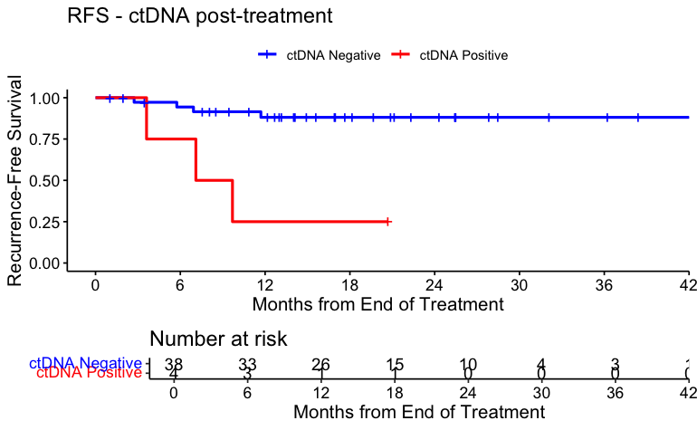

```r
surv_object <-Surv(time = circ_data$RFS.months, event = circ_data$RFS.Event.1y)
KM_curve <- survfit(surv_object ~ ctDNA.postTx, data = circ_data,conf.int=0.95,conf.type="log-log")
ggsurvplot(KM_curve, data = circ_data, pval = FALSE, conf.int = FALSE, risk.table = TRUE, break.time.by=6, palette=c("blue","red"), title="RFS - ctDNA post-treatment", ylab= "Recurrence-Free Survival", xlab="Months from End of Treatment", legend.labs=c("ctDNA Negative", "ctDNA Positive"), legend.title="")
```

```r
summary(KM_curve, times= c(0, 12, 24, 36))
```

```
Call: survfit(formula = surv_object ~ ctDNA.postTx, data = circ_data,
    conf.int = 0.95, conf.type = "log-log")

                ctDNA.postTx=NEGATIVE
 time n.risk n.event survival std.err lower 95% CI upper 95% CI
    0     38       0    1.000  0.0000        1.000        1.000
   12     26       4    0.881  0.0561        0.712        0.954
   24     10       0    0.881  0.0561        0.712        0.954
   36      3       0    0.881  0.0561        0.712        0.954

                ctDNA.postTx=POSITIVE
 time n.risk n.event survival std.err lower 95% CI upper 95% CI
    0      4       0     1.00   0.000      1.00000        1.000
   12      1       3     0.25   0.217      0.00895        0.665
```

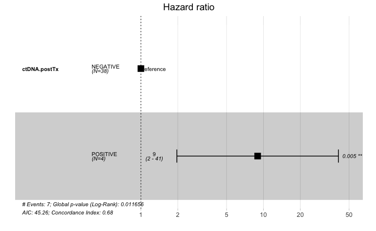

```r
circ_data$ctDNA.postTx <- factor(circ_data$ctDNA.postTx, levels=c("NEGATIVE","POSITIVE"))
cox_fit <- coxph(surv_object ~ ctDNA.postTx, data=circ_data)
ggforest(cox_fit,data = circ_data)
```

```r
summary(cox_fit)
```

```
Call:
coxph(formula = surv_object ~ ctDNA.postTx, data = circ_data)

  n= 42, number of events= 7

                       coef exp(coef) se(coef)     z Pr(>|z|)
ctDNA.postTxPOSITIVE 2.1937    8.9685   0.7745 2.832  0.00462 **
---
Signif. codes:  0 ‘***’ 0.001 ‘**’ 0.01 ‘*’ 0.05 ‘.’ 0.1 ‘ ’ 1

                     exp(coef) exp(-coef) lower .95 upper .95
ctDNA.postTxPOSITIVE     8.969     0.1115     1.966     40.92

Concordance= 0.675  (se = 0.088 )
Likelihood ratio test= 6.36  on 1 df,   p=0.01
Wald test            = 8.02  on 1 df,   p=0.005
Score (logrank) test = 11.69  on 1 df,   p=6e-04
```

```r
cox_fit_summary <- summary(cox_fit)

#Extract values for HR, 95% CI, and p-value
HR <- cox_fit_summary$coefficients[2]
lower_CI <- cox_fit_summary$conf.int[3]
upper_CI <- cox_fit_summary$conf.int[4]
p_value <- cox_fit_summary$coefficients[5]
label_text <- paste0("HR = ", round(HR, 2), " (", round(lower_CI, 2), "-", round(upper_CI, 2), "); p = ", round(p_value, 3))
print(label_text)
```

```
[1] "HR = 8.97 (1.97-40.92); p = 0.005"
```

```r
#Fisher test for RFS percentages at 12, 24, and 36 months
dfs_times <- c(12, 24, 36)
p_values <- sapply(dfs_times, function(time) {
  neg_count <- sum(circ_data$ctDNA.postTx == "NEGATIVE" & circ_data$RFS.months >= time & circ_data$RFS.Event.1y == 0)
  pos_count <- sum(circ_data$ctDNA.postTx == "POSITIVE" & circ_data$RFS.months >= time & circ_data$RFS.Event.1y == 0)
  neg_total <- sum(circ_data$ctDNA.postTx == "NEGATIVE")
  pos_total <- sum(circ_data$ctDNA.postTx == "POSITIVE")

  neg_surv <- neg_total - sum(circ_data$ctDNA.postTx == "NEGATIVE" & circ_data$RFS.Event.1y == 1 & circ_data$RFS.months < time)
  pos_surv <- pos_total - sum(circ_data$ctDNA.postTx == "POSITIVE" & circ_data$RFS.Event.1y == 1 & circ_data$RFS.months < time)

  surv_matrix <- matrix(c(neg_surv, pos_surv, neg_total - neg_surv, pos_total - pos_surv), nrow = 2)
  test_result <- fisher.test(surv_matrix)
  return(test_result$p.value)
})
names(p_values) <- paste0("p-value at ", dfs_times, " months")
print(p_values)
```

```
p-value at 12 months p-value at 24 months p-value at 36 months
          0.01125704           0.01125704           0.01125704
```

#Barplot for Recurrence % at year 1 by ctDNA post-treatment

```r
rm(list=ls())
setwd("~/Downloads")
circ_data <- read.csv("OP-16933_HNSCC Clinical data.csv")
circ_data <- circ_data[circ_data$ctDNA.available=="TRUE",]
circ_data <- circ_data[circ_data$ctDNA.postTx!="",]

circ_data$ctDNA.postTx <- factor(circ_data$ctDNA.postTx, levels = c("NEGATIVE", "POSITIVE"), labels = c("Negative", "Positive"))
circ_data$RFS.Event.1y <- factor(circ_data$RFS.Event.1y, levels = c("FALSE", "TRUE"), labels = c("No Recurrence", "Recurrence"))
contingency_table <- table(circ_data$ctDNA.postTx, circ_data$RFS.Event.1y)
chi_square_test <- chisq.test(contingency_table)
print(chi_square_test)
```

```
    Pearson's Chi-squared test with Yates' continuity correction

data:  contingency_table
X-squared = 6.6868, df = 1, p-value = 0.009713
```

```r
fisher_exact_test <- fisher.test(contingency_table)
print(fisher_exact_test)
```

```
    Fisher's Exact Test for Count Data

data:  contingency_table
p-value = 0.01126
alternative hypothesis: true odds ratio is not equal to 1
95 percent confidence interval:
    1.421207 1359.954433
sample estimates:
odds ratio
  22.02536
```

```r
print(contingency_table)
```

```
           No Recurrence Recurrence
  Negative            34          4
  Positive             1          3
```

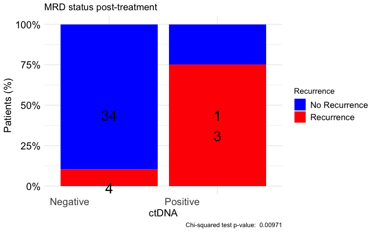

```r
table_df <- as.data.frame(contingency_table)
table_df$Total <- ave(table_df$Freq, table_df$Var1, FUN = sum)
table_df$Percentage <- table_df$Freq / table_df$Total
table_df$MiddlePercentage <- table_df$Percentage / 2
ggplot(table_df, aes(x = Var1, y = Percentage, fill = Var2)) +
  geom_bar(stat = "identity") +
  geom_text(aes(y = MiddlePercentage, label = Freq), position = "stack", color = "black", vjust = 1.5, size = 7) +
  theme_minimal() +
  labs(title = "MRD status post-treatment",
       x = "ctDNA",
       y = "Patients (%)",
       fill = "Recurrence",
       caption = paste("Chi-squared test p-value: ", format.pval(chi_square_test$p.value))) +
  scale_y_continuous(labels = scales::percent_format()) +
  scale_fill_manual(values = c("No Recurrence" = "blue", "Recurrence" = "red")) + # define custom colors
  theme(axis.text.x = element_text(angle = 0, hjust = 1.5, size = 14), # increase x-axis text size
        axis.text.y = element_text(size = 14, color = "black"), # increase y-axis text size
        axis.title.x = element_text(size = 14, color = "black"), # increase x-axis label size
        axis.title.y = element_text(size = 14, color = "black"), # increase y-axis label size
        legend.text = element_text(size = 12, color = "black"))  # increase Recurrence label size
```

#OS by ctDNA post-treatment

```r
rm(list=ls())
setwd("~/Downloads")
circ_data <- read.csv("OP-16933_HNSCC Clinical data.csv")
circ_data <- circ_data[circ_data$ctDNA.available=="TRUE",]
circ_data <- circ_data[circ_data$ctDNA.postTx!="",]
circ_datadf <- as.data.frame(circ_data)

survfit(Surv(time = circ_data$FU.Biopsy.months, event = circ_data$OS.Event)~ctDNA.postTx, data = circ_data)
```

```
Call: survfit(formula = Surv(time = circ_data$FU.Biopsy.months, event = circ_data$OS.Event) ~
    ctDNA.postTx, data = circ_data)

                       n events median 0.95LCL 0.95UCL
ctDNA.postTx=NEGATIVE 38      8     NA    29.5      NA
ctDNA.postTx=POSITIVE  4      2   15.6    13.1      NA
```

```r
event_summary <- circ_data %>%
  group_by(ctDNA.postTx) %>%
  summarise(
    Total = n(),
    Events = sum(OS.Event),
    Fraction = Events / n(),
    Percentage = (Events / n()) * 100
  )
print(event_summary)
```

| ctDNA.postTx | Total | Events | Fraction | Percentage |
| --- | --- | --- | --- | --- |
| NEGATIVE | 38 | 8 | 0.2105263 | 21.05263 |
| POSITIVE | 4 | 2 | 0.5000000 | 50.00000 |

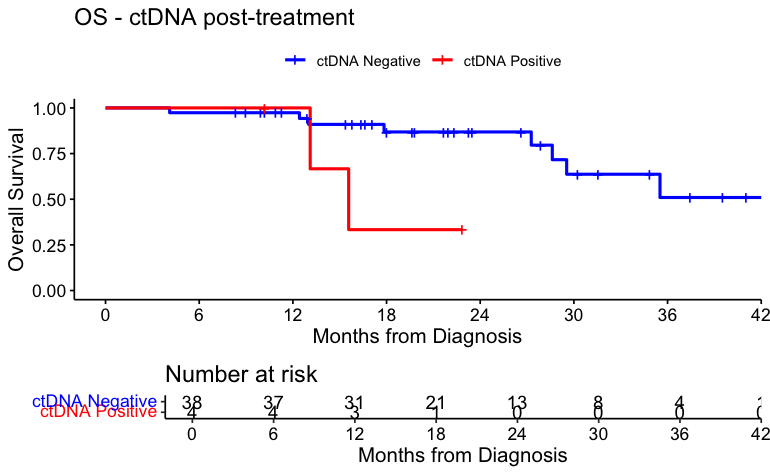

```r
surv_object <-Surv(time = circ_data$FU.Biopsy.months, event = circ_data$OS.Event)
KM_curve <- survfit(surv_object ~ ctDNA.postTx, data = circ_data,conf.int=0.95,conf.type="log-log")
ggsurvplot(KM_curve, data = circ_data, pval = FALSE, conf.int = FALSE, risk.table = TRUE, break.time.by=6, palette=c("blue","red"), title="OS - ctDNA post-treatment", ylab= "Overall Survival", xlab="Months from Diagnosis", legend.labs=c("ctDNA Negative", "ctDNA Positive"), legend.title="")
```

```r
summary(KM_curve, times= c(0, 24, 36))
```

```
Call: survfit(formula = surv_object ~ ctDNA.postTx, data = circ_data,
    conf.int = 0.95, conf.type = "log-log")

                ctDNA.postTx=NEGATIVE
 time n.risk n.event survival std.err lower 95% CI upper 95% CI
    0     38       0    1.000  0.0000        1.000        1.000
   24     13       4    0.868  0.0625        0.681        0.949
   36      4       4    0.509  0.1509        0.203        0.752

                ctDNA.postTx=POSITIVE
        time       n.risk      n.event     survival      std.err lower 95% CI upper 95% CI
           0            4            0            1            0            1            1
```

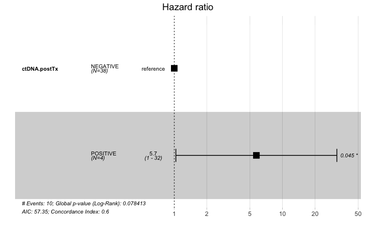

```r
circ_data$ctDNA.postTx <- factor(circ_data$ctDNA.postTx, levels=c("NEGATIVE","POSITIVE"))
cox_fit <- coxph(surv_object ~ ctDNA.postTx, data=circ_data)
ggforest(cox_fit,data = circ_data)
```

```r
summary(cox_fit)
```

```
Call:
coxph(formula = surv_object ~ ctDNA.postTx, data = circ_data)

  n= 42, number of events= 10

                       coef exp(coef) se(coef) z Pr(>|z|)
ctDNA.postTxPOSITIVE 1.7472    5.7385   0.8736 2   0.0455 *
---
Signif. codes:  0 ‘***’ 0.001 ‘**’ 0.01 ‘*’ 0.05 ‘.’ 0.1 ‘ ’ 1

                     exp(coef) exp(-coef) lower .95 upper .95
ctDNA.postTxPOSITIVE     5.738     0.1743     1.036      31.8

Concordance= 0.6  (se = 0.074 )
Likelihood ratio test= 3.1  on 1 df,   p=0.08
Wald test            = 4  on 1 df,   p=0.05
Score (logrank) test = 5.11  on 1 df,   p=0.02
```

```r
cox_fit_summary <- summary(cox_fit)

#Extract values for HR, 95% CI, and p-value
HR <- cox_fit_summary$coefficients[2]
lower_CI <- cox_fit_summary$conf.int[3]
upper_CI <- cox_fit_summary$conf.int[4]
p_value <- cox_fit_summary$coefficients[5]
label_text <- paste0("HR = ", round(HR, 2), " (", round(lower_CI, 2), "-", round(upper_CI, 2), "); p = ", round(p_value, 3))
print(label_text)
```

```
[1] "HR = 5.74 (1.04-31.8); p = 0.045"
```

```r
#Fisher test for RFS percentages at 12, 24, and 36 months
dfs_times <- c(12, 24, 36)
p_values <- sapply(dfs_times, function(time) {
  neg_count <- sum(circ_data$ctDNA.postTx == "NEGATIVE" & circ_data$FU.Biopsy.months >= time & circ_data$OS.Event == 0)
  pos_count <- sum(circ_data$ctDNA.postTx == "POSITIVE" & circ_data$FU.Biopsy.months >= time & circ_data$OS.Event == 0)
  neg_total <- sum(circ_data$ctDNA.postTx == "NEGATIVE")
  pos_total <- sum(circ_data$ctDNA.postTx == "POSITIVE")

  neg_surv <- neg_total - sum(circ_data$ctDNA.postTx == "NEGATIVE" & circ_data$OS.Event == 1 & circ_data$FU.Biopsy.months < time)
  pos_surv <- pos_total - sum(circ_data$ctDNA.postTx == "POSITIVE" & circ_data$OS.Event == 1 & circ_data$FU.Biopsy.months < time)

  surv_matrix <- matrix(c(neg_surv, pos_surv, neg_total - neg_surv, pos_total - pos_surv), nrow = 2)
  test_result <- fisher.test(surv_matrix)
  return(test_result$p.value)
})
names(p_values) <- paste0("p-value at ", dfs_times, " months")
print(p_values)
```

```
p-value at 12 months p-value at 24 months p-value at 36 months
          1.00000000           0.09099437           0.23559367
```

#Barplot for Death % by ctDNA post-treatment

```r
rm(list=ls())
setwd("~/Downloads")
circ_data <- read.csv("OP-16933_HNSCC Clinical data.csv")
circ_data <- circ_data[circ_data$ctDNA.available=="TRUE",]
circ_data <- circ_data[circ_data$ctDNA.postTx!="",]

circ_data$ctDNA.postTx <- factor(circ_data$ctDNA.postTx, levels = c("NEGATIVE", "POSITIVE"), labels = c("Negative", "Positive"))
circ_data$OS.Event <- factor(circ_data$OS.Event, levels = c("FALSE", "TRUE"), labels = c("Alive", "Deceased"))
contingency_table <- table(circ_data$ctDNA.postTx, circ_data$OS.Event)
chi_square_test <- chisq.test(contingency_table)
print(chi_square_test)
```

```
    Pearson's Chi-squared test with Yates' continuity correction

data:  contingency_table
X-squared = 0.45678, df = 1, p-value = 0.4991
```

```r
fisher_exact_test <- fisher.test(contingency_table)
print(fisher_exact_test)
```

```
    Fisher's Exact Test for Count Data

data:  contingency_table
p-value = 0.2356
alternative hypothesis: true odds ratio is not equal to 1
95 percent confidence interval:
  0.2285925 57.0740405
sample estimates:
odds ratio
  3.604577
```

```r
print(contingency_table)
```

```
           Alive Deceased
  Negative    30        8
  Positive     2        2
```

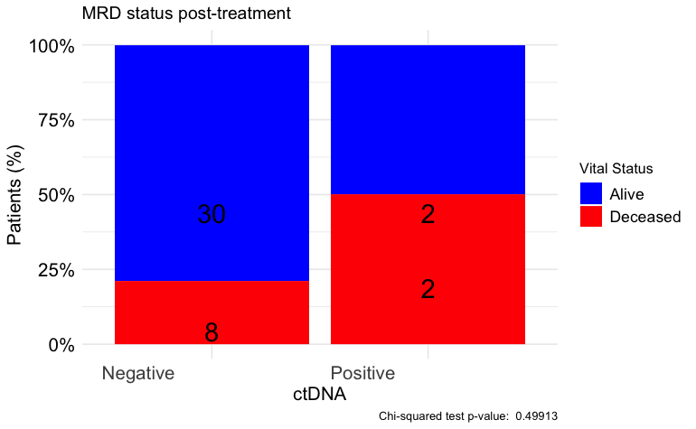

```r
table_df <- as.data.frame(contingency_table)
table_df$Total <- ave(table_df$Freq, table_df$Var1, FUN = sum)
table_df$Percentage <- table_df$Freq / table_df$Total
table_df$MiddlePercentage <- table_df$Percentage / 2
ggplot(table_df, aes(x = Var1, y = Percentage, fill = Var2)) +
  geom_bar(stat = "identity") +
  geom_text(aes(y = MiddlePercentage, label = Freq), position = "stack", color = "black", vjust = 1.5, size = 7) +
  theme_minimal() +
  labs(title = "MRD status post-treatment",
       x = "ctDNA",
       y = "Patients (%)",
       fill = "Vital Status",
       caption = paste("Chi-squared test p-value: ", format.pval(chi_square_test$p.value))) +
  scale_y_continuous(labels = scales::percent_format()) +
  scale_fill_manual(values = c("Alive" = "blue", "Deceased" = "red")) + # define custom colors
  theme(axis.text.x = element_text(angle = 0, hjust = 1.5, size = 14), # increase x-axis text size
        axis.text.y = element_text(size = 14, color = "black"), # increase y-axis text size
        axis.title.x = element_text(size = 14, color = "black"), # increase x-axis label size
        axis.title.y = element_text(size = 14, color = "black"), # increase y-axis label size
        legend.text = element_text(size = 12, color = "black"))  # increase Recurrence label size
```

#Multivariate cox regression for RFS

```r
rm(list=ls())
setwd("~/Downloads")
circ_data <- read.csv("OP-16933_HNSCC Clinical data.csv")
circ_data <- circ_data[circ_data$ctDNA.available=="TRUE",]
circ_data <- circ_data[circ_data$ctDNA.postTx!="",]
circ_datadf <- as.data.frame(circ_data)

circ_data$ctDNA.postTx <- factor(circ_data$ctDNA.postTx, levels=c("NEGATIVE","POSITIVE"), labels = c("Negative", "Positive"))
circ_data$Gender <- factor(circ_data$Gender, levels = c("Female", "Male"), labels = c("Female", "Male"))
circ_data$Location <- factor(circ_data$Location, levels = c("Oropharynx/Oral", "Larynx"))
circ_data$ECOG.score <- factor(circ_data$ECOG.score, levels = c("0", "1"), labels = c("0", "1/2"))
circ_data$cStage <- factor(circ_data$cStage, levels = c("III", "IV"))
circ_data$NAC <- factor(circ_data$NAC, levels = c("TRUE", "FALSE"))
circ_data$p16 <- factor(circ_data$p16, levels = c("Positive", "Negative"))
surv_object <- Surv(time = circ_data$RFS.months, event = circ_data$RFS.Event)
cox_fit <- coxph(surv_object ~ ctDNA.postTx + Location + cStage + ECOG.score + p16, data=circ_data)
ggforest(cox_fit, data = circ_data, main = "Multivariate Regression Model for RFS", refLabel = "Reference Group")
test.ph <- cox.zph(cox_fit)
```

[output not shown]

#Univariate RFS cox regression for variables included in MVA

```r
rm(list=ls())
setwd("~/Downloads")
circ_data <- read.csv("OP-16933_HNSCC Clinical data.csv")
circ_data <- circ_data[circ_data$ctDNA.available=="TRUE",]
circ_data <- circ_data[circ_data$ctDNA.postTx!="",]
surv_object <-Surv(time = circ_data$RFS.months, event = circ_data$RFS.Event)
circ_data$ctDNA.postTx <- factor(circ_data$ctDNA.postTx, levels=c("NEGATIVE","POSITIVE"), labels = c("Negative", "Positive")) #univariate for ctDNA post-treatment
cox_fit <- coxph(surv_object ~ ctDNA.postTx, data=circ_data)
summary(cox_fit)
cox_fit_summary <- summary(cox_fit)

#Extract values for HR, 95% CI, and p-value
HR <- cox_fit_summary$coefficients[2]
lower_CI <- cox_fit_summary$conf.int[3]
upper_CI <- cox_fit_summary$conf.int[4]
p_value <- cox_fit_summary$coefficients[5]
label_text <- paste0("HR = ", round(HR, 2), " (", round(lower_CI, 2), "-", round(upper_CI, 2), "); p = ", round(p_value, 3))
print(label_text)

rm(list=ls())
setwd("~/Downloads")
circ_data <- read.csv("OP-16933_HNSCC Clinical data.csv")
circ_data <- circ_data[circ_data$ctDNA.available=="TRUE",]
circ_data <- circ_data[circ_data$ctDNA.postTx!="",]
surv_object <-Surv(time = circ_data$RFS.months, event = circ_data$RFS.Event)
circ_data$Location <- factor(circ_data$Location, levels = c("Oropharynx/Oral", "Larynx")) #univariate for Primary location
cox_fit <- coxph(surv_object ~ Location, data=circ_data)
summary(cox_fit)
cox_fit_summary <- summary(cox_fit)

#Extract values for HR, 95% CI, and p-value
HR <- cox_fit_summary$coefficients[2]
lower_CI <- cox_fit_summary$conf.int[3]
upper_CI <- cox_fit_summary$conf.int[4]
p_value <- cox_fit_summary$coefficients[5]
label_text <- paste0("HR = ", round(HR, 2), " (", round(lower_CI, 2), "-", round(upper_CI, 2), "); p = ", round(p_value, 3))
print(label_text)

rm(list=ls())
setwd("~/Downloads")
circ_data <- read.csv("OP-16933_HNSCC Clinical data.csv")
circ_data <- circ_data[circ_data$ctDNA.available=="TRUE",]
circ_data <- circ_data[circ_data$ctDNA.postTx!="",]
surv_object <-Surv(time = circ_data$RFS.months, event = circ_data$RFS.Event)
circ_data$cStage <- factor(circ_data$cStage, levels = c("III", "IV")) #univariate for Stage
cox_fit <- coxph(surv_object ~ cStage, data=circ_data)
summary(cox_fit)
cox_fit_summary <- summary(cox_fit)

#Extract values for HR, 95% CI, and p-value
HR <- cox_fit_summary$coefficients[2]
lower_CI <- cox_fit_summary$conf.int[3]
upper_CI <- cox_fit_summary$conf.int[4]
p_value <- cox_fit_summary$coefficients[5]
label_text <- paste0("HR = ", round(HR, 2), " (", round(lower_CI, 2), "-", round(upper_CI, 2), "); p = ", round(p_value, 3))
print(label_text)

rm(list=ls())
setwd("~/Downloads")
circ_data <- read.csv("OP-16933_HNSCC Clinical data.csv")
circ_data <- circ_data[circ_data$ctDNA.available=="TRUE",]
circ_data <- circ_data[circ_data$ctDNA.postTx!="",]
surv_object <-Surv(time = circ_data$RFS.months, event = circ_data$RFS.Event)
circ_data$ECOG.score <- factor(circ_data$ECOG.score, levels = c("0", "1"), labels = c("0", "1/2")) #univariate for ECOG
cox_fit <- coxph(surv_object ~ ECOG.score, data=circ_data)
summary(cox_fit)
cox_fit_summary <- summary(cox_fit)

#Extract values for HR, 95% CI, and p-value
HR <- cox_fit_summary$coefficients[2]
lower_CI <- cox_fit_summary$conf.int[3]
upper_CI <- cox_fit_summary$conf.int[4]
p_value <- cox_fit_summary$coefficients[5]
label_text <- paste0("HR = ", round(HR, 2), " (", round(lower_CI, 2), "-", round(upper_CI, 2), "); p = ", round(p_value, 3))
print(label_text)

rm(list=ls())
setwd("~/Downloads")
circ_data <- read.csv("OP-16933_HNSCC Clinical data.csv")
circ_data <- circ_data[circ_data$ctDNA.available=="TRUE",]
circ_data <- circ_data[circ_data$ctDNA.postTx!="",]
surv_object <-Surv(time = circ_data$RFS.months, event = circ_data$RFS.Event)
circ_data$p16 <- factor(circ_data$p16, levels = c("Positive", "Negative")) #univariate for p16
cox_fit <- coxph(surv_object ~ p16, data=circ_data)
summary(cox_fit)
cox_fit_summary <- summary(cox_fit)

#Extract values for HR, 95% CI, and p-value
HR <- cox_fit_summary$coefficients[2]
lower_CI <- cox_fit_summary$conf.int[3]
upper_CI <- cox_fit_summary$conf.int[4]
p_value <- cox_fit_summary$coefficients[5]
label_text <- paste0("HR = ", round(HR, 2), " (", round(lower_CI, 2), "-", round(upper_CI, 2), "); p = ", round(p_value, 3))
print(label_text)
```

[output not shown]

#Multivariate cox regression for RFS - Recurrence at year 1

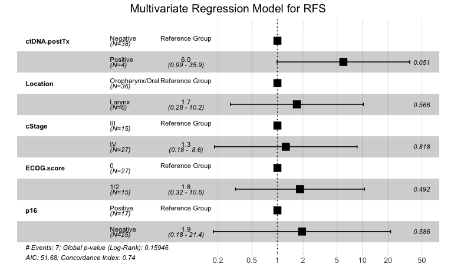

```r
rm(list=ls())
setwd("~/Downloads")
circ_data <- read.csv("OP-16933_HNSCC Clinical data.csv")
circ_data <- circ_data[circ_data$ctDNA.available=="TRUE",]
circ_data <- circ_data[circ_data$ctDNA.postTx!="",]
circ_datadf <- as.data.frame(circ_data)

circ_data$ctDNA.postTx <- factor(circ_data$ctDNA.postTx, levels=c("NEGATIVE","POSITIVE"), labels = c("Negative", "Positive"))
circ_data$Gender <- factor(circ_data$Gender, levels = c("Female", "Male"), labels = c("Female", "Male"))
circ_data$Location <- factor(circ_data$Location, levels = c("Oropharynx/Oral", "Larynx"))
circ_data$ECOG.score <- factor(circ_data$ECOG.score, levels = c("0", "1"), labels = c("0", "1/2"))
circ_data$cStage <- factor(circ_data$cStage, levels = c("III", "IV"))
circ_data$NAC <- factor(circ_data$NAC, levels = c("TRUE", "FALSE"))
circ_data$p16 <- factor(circ_data$p16, levels = c("Positive", "Negative"))
surv_object <- Surv(time = circ_data$RFS.months, event = circ_data$RFS.Event.1y)
cox_fit <- coxph(surv_object ~ ctDNA.postTx + Location + cStage + ECOG.score + p16, data=circ_data)
ggforest(cox_fit, data = circ_data, main = "Multivariate Regression Model for RFS", refLabel = "Reference Group")
```

```r
test.ph <- cox.zph(cox_fit)
```

#Univariate RFS cox regression for variables included in MVA - Recurrence at year 1

```r
rm(list=ls())
setwd("~/Downloads")
circ_data <- read.csv("OP-16933_HNSCC Clinical data.csv")
circ_data <- circ_data[circ_data$ctDNA.available=="TRUE",]
circ_data <- circ_data[circ_data$ctDNA.postTx!="",]
surv_object <-Surv(time = circ_data$RFS.months, event = circ_data$RFS.Event.1y)
circ_data$ctDNA.postTx <- factor(circ_data$ctDNA.postTx, levels=c("NEGATIVE","POSITIVE"), labels = c("Negative", "Positive")) #univariate for ctDNA post-treatment
cox_fit <- coxph(surv_object ~ ctDNA.postTx, data=circ_data)
summary(cox_fit)
```

```
Call:
coxph(formula = surv_object ~ ctDNA.postTx, data = circ_data)

  n= 42, number of events= 7

                       coef exp(coef) se(coef)     z Pr(>|z|)
ctDNA.postTxPositive 2.1937    8.9685   0.7745 2.832  0.00462 **
---
Signif. codes:  0 ‘***’ 0.001 ‘**’ 0.01 ‘*’ 0.05 ‘.’ 0.1 ‘ ’ 1

                     exp(coef) exp(-coef) lower .95 upper .95
ctDNA.postTxPositive     8.969     0.1115     1.966     40.92

Concordance= 0.675  (se = 0.088 )
Likelihood ratio test= 6.36  on 1 df,   p=0.01
Wald test            = 8.02  on 1 df,   p=0.005
Score (logrank) test = 11.69  on 1 df,   p=6e-04
```

```r
cox_fit_summary <- summary(cox_fit)

#Extract values for HR, 95% CI, and p-value
HR <- cox_fit_summary$coefficients[2]
lower_CI <- cox_fit_summary$conf.int[3]
upper_CI <- cox_fit_summary$conf.int[4]
p_value <- cox_fit_summary$coefficients[5]
label_text <- paste0("HR = ", round(HR, 2), " (", round(lower_CI, 2), "-", round(upper_CI, 2), "); p = ", round(p_value, 3))
print(label_text)
```

```
[1] "HR = 8.97 (1.97-40.92); p = 0.005"
```

```r
rm(list=ls())
setwd("~/Downloads")
circ_data <- read.csv("OP-16933_HNSCC Clinical data.csv")
circ_data <- circ_data[circ_data$ctDNA.available=="TRUE",]
circ_data <- circ_data[circ_data$ctDNA.postTx!="",]
surv_object <-Surv(time = circ_data$RFS.months, event = circ_data$RFS.Event.1y)
circ_data$Location <- factor(circ_data$Location, levels = c("Oropharynx/Oral", "Larynx")) #univariate for Primary location
cox_fit <- coxph(surv_object ~ Location, data=circ_data)
summary(cox_fit)
```

```
Call:
coxph(formula = surv_object ~ Location, data = circ_data)

  n= 42, number of events= 7

                 coef exp(coef) se(coef)     z Pr(>|z|)
LocationLarynx 0.9057    2.4737   0.8369 1.082    0.279

               exp(coef) exp(-coef) lower .95 upper .95
LocationLarynx     2.474     0.4042    0.4797     12.76

Concordance= 0.586  (se = 0.089 )
Likelihood ratio test= 1.01  on 1 df,   p=0.3
Wald test            = 1.17  on 1 df,   p=0.3
Score (logrank) test = 1.25  on 1 df,   p=0.3
```

```r
cox_fit_summary <- summary(cox_fit)

#Extract values for HR, 95% CI, and p-value
HR <- cox_fit_summary$coefficients[2]
lower_CI <- cox_fit_summary$conf.int[3]
upper_CI <- cox_fit_summary$conf.int[4]
p_value <- cox_fit_summary$coefficients[5]
label_text <- paste0("HR = ", round(HR, 2), " (", round(lower_CI, 2), "-", round(upper_CI, 2), "); p = ", round(p_value, 3))
print(label_text)
```

```
[1] "HR = 2.47 (0.48-12.76); p = 0.279"
```

```r
rm(list=ls())
setwd("~/Downloads")
circ_data <- read.csv("OP-16933_HNSCC Clinical data.csv")
circ_data <- circ_data[circ_data$ctDNA.available=="TRUE",]
circ_data <- circ_data[circ_data$ctDNA.postTx!="",]
surv_object <-Surv(time = circ_data$RFS.months, event = circ_data$RFS.Event.1y)
circ_data$cStage <- factor(circ_data$cStage, levels = c("III", "IV")) #univariate for Stage
cox_fit <- coxph(surv_object ~ cStage, data=circ_data)
summary(cox_fit)
```

```
Call:
coxph(formula = surv_object ~ cStage, data = circ_data)

  n= 42, number of events= 7

            coef exp(coef) se(coef)      z Pr(>|z|)
cStageIV -0.2073    0.8128   0.7650 -0.271    0.786

         exp(coef) exp(-coef) lower .95 upper .95
cStageIV    0.8128       1.23    0.1815      3.64

Concordance= 0.519  (se = 0.094 )
Likelihood ratio test= 0.07  on 1 df,   p=0.8
Wald test            = 0.07  on 1 df,   p=0.8
Score (logrank) test = 0.07  on 1 df,   p=0.8
```

```r
cox_fit_summary <- summary(cox_fit)

#Extract values for HR, 95% CI, and p-value
HR <- cox_fit_summary$coefficients[2]
lower_CI <- cox_fit_summary$conf.int[3]
upper_CI <- cox_fit_summary$conf.int[4]
p_value <- cox_fit_summary$coefficients[5]
label_text <- paste0("HR = ", round(HR, 2), " (", round(lower_CI, 2), "-", round(upper_CI, 2), "); p = ", round(p_value, 3))
print(label_text)
```

```
[1] "HR = 0.81 (0.18-3.64); p = 0.786"
```

```r
rm(list=ls())
setwd("~/Downloads")
circ_data <- read.csv("OP-16933_HNSCC Clinical data.csv")
circ_data <- circ_data[circ_data$ctDNA.available=="TRUE",]
circ_data <- circ_data[circ_data$ctDNA.postTx!="",]
surv_object <-Surv(time = circ_data$RFS.months, event = circ_data$RFS.Event.1y)
circ_data$ECOG.score <- factor(circ_data$ECOG.score, levels = c("0", "1"), labels = c("0", "1/2")) #univariate for ECOG
cox_fit <- coxph(surv_object ~ ECOG.score, data=circ_data)
summary(cox_fit)
```

```
Call:
coxph(formula = surv_object ~ ECOG.score, data = circ_data)

  n= 42, number of events= 7

                coef exp(coef) se(coef)    z Pr(>|z|)
ECOG.score1/2 1.1173    3.0567   0.7654 1.46    0.144

              exp(coef) exp(-coef) lower .95 upper .95
ECOG.score1/2     3.057     0.3272    0.6819      13.7

Concordance= 0.643  (se = 0.092 )
Likelihood ratio test= 2.14  on 1 df,   p=0.1
Wald test            = 2.13  on 1 df,   p=0.1
Score (logrank) test = 2.36  on 1 df,   p=0.1
```

```r
cox_fit_summary <- summary(cox_fit)

#Extract values for HR, 95% CI, and p-value
HR <- cox_fit_summary$coefficients[2]
lower_CI <- cox_fit_summary$conf.int[3]
upper_CI <- cox_fit_summary$conf.int[4]
p_value <- cox_fit_summary$coefficients[5]
label_text <- paste0("HR = ", round(HR, 2), " (", round(lower_CI, 2), "-", round(upper_CI, 2), "); p = ", round(p_value, 3))
print(label_text)
```

```
[1] "HR = 3.06 (0.68-13.7); p = 0.144"
```

```r
rm(list=ls())
setwd("~/Downloads")
circ_data <- read.csv("OP-16933_HNSCC Clinical data.csv")
circ_data <- circ_data[circ_data$ctDNA.available=="TRUE",]
circ_data <- circ_data[circ_data$ctDNA.postTx!="",]
surv_object <-Surv(time = circ_data$RFS.months, event = circ_data$RFS.Event.1y)
circ_data$p16 <- factor(circ_data$p16, levels = c("Positive", "Negative")) #univariate for p16
cox_fit <- coxph(surv_object ~ p16, data=circ_data)
summary(cox_fit)
```

```
Call:
coxph(formula = surv_object ~ p16, data = circ_data)

  n= 42, number of events= 7

             coef exp(coef) se(coef)    z Pr(>|z|)
p16Negative 1.459     4.304    1.081 1.35    0.177

            exp(coef) exp(-coef) lower .95 upper .95
p16Negative     4.304     0.2324    0.5173      35.8

Concordance= 0.654  (se = 0.059 )
Likelihood ratio test= 2.49  on 1 df,   p=0.1
Wald test            = 1.82  on 1 df,   p=0.2
Score (logrank) test = 2.17  on 1 df,   p=0.1
```

```r
cox_fit_summary <- summary(cox_fit)

#Extract values for HR, 95% CI, and p-value
HR <- cox_fit_summary$coefficients[2]
lower_CI <- cox_fit_summary$conf.int[3]
upper_CI <- cox_fit_summary$conf.int[4]
p_value <- cox_fit_summary$coefficients[5]
label_text <- paste0("HR = ", round(HR, 2), " (", round(lower_CI, 2), "-", round(upper_CI, 2), "); p = ", round(p_value, 3))
print(label_text)
```

```
[1] "HR = 4.3 (0.52-35.8); p = 0.177"
```

#Multivariate cox regression for OS

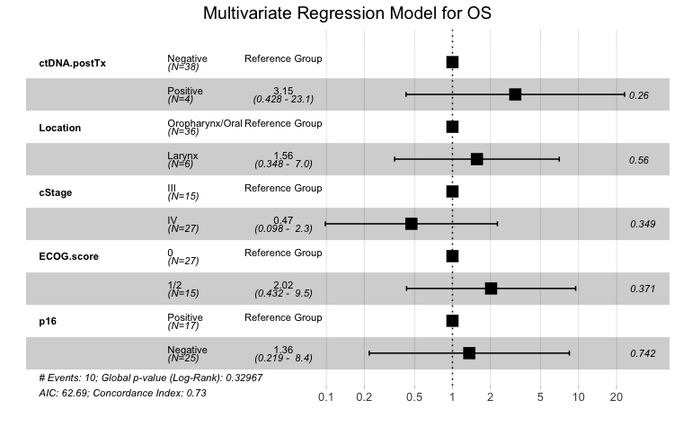

```r
rm(list=ls())
setwd("~/Downloads")
circ_data <- read.csv("OP-16933_HNSCC Clinical data.csv")
circ_data <- circ_data[circ_data$ctDNA.available=="TRUE",]
circ_data <- circ_data[circ_data$ctDNA.postTx!="",]
circ_datadf <- as.data.frame(circ_data)

circ_data$ctDNA.postTx <- factor(circ_data$ctDNA.postTx, levels=c("NEGATIVE","POSITIVE"), labels = c("Negative", "Positive"))
circ_data$Gender <- factor(circ_data$Gender, levels = c("Female", "Male"), labels = c("Female", "Male"))
circ_data$Location <- factor(circ_data$Location, levels = c("Oropharynx/Oral", "Larynx"))
circ_data$ECOG.score <- factor(circ_data$ECOG.score, levels = c("0", "1"), labels = c("0", "1/2"))
circ_data$cStage <- factor(circ_data$cStage, levels = c("III", "IV"))
circ_data$NAC <- factor(circ_data$NAC, levels = c("TRUE", "FALSE"))
circ_data$p16 <- factor(circ_data$p16, levels = c("Positive", "Negative"))
surv_object <- Surv(time = circ_data$FU.Biopsy.months, event = circ_data$OS.Event)
cox_fit <- coxph(surv_object ~ ctDNA.postTx + Location + cStage + ECOG.score + p16, data=circ_data)
ggforest(cox_fit, data = circ_data, main = "Multivariate Regression Model for OS", refLabel = "Reference Group")
```

```r
test.ph <- cox.zph(cox_fit)
```

#Univariate OS cox regression for variables included in MVA

```r
rm(list=ls())
setwd("~/Downloads")
circ_data <- read.csv("OP-16933_HNSCC Clinical data.csv")
circ_data <- circ_data[circ_data$ctDNA.available=="TRUE",]
circ_data <- circ_data[circ_data$ctDNA.postTx!="",]
surv_object <-Surv(time = circ_data$FU.Biopsy.months, event = circ_data$OS.Event)
circ_data$ctDNA.postTx <- factor(circ_data$ctDNA.postTx, levels=c("NEGATIVE","POSITIVE"), labels = c("Negative", "Positive")) #univariate for ctDNA post-treatment
cox_fit <- coxph(surv_object ~ ctDNA.postTx, data=circ_data)
summary(cox_fit)
```

```
Call:
coxph(formula = surv_object ~ ctDNA.postTx, data = circ_data)

  n= 42, number of events= 10

                       coef exp(coef) se(coef) z Pr(>|z|)
ctDNA.postTxPositive 1.7472    5.7385   0.8736 2   0.0455 *
---
Signif. codes:  0 ‘***’ 0.001 ‘**’ 0.01 ‘*’ 0.05 ‘.’ 0.1 ‘ ’ 1

                     exp(coef) exp(-coef) lower .95 upper .95
ctDNA.postTxPositive     5.738     0.1743     1.036      31.8

Concordance= 0.6  (se = 0.074 )
Likelihood ratio test= 3.1  on 1 df,   p=0.08
Wald test            = 4  on 1 df,   p=0.05
Score (logrank) test = 5.11  on 1 df,   p=0.02
```

```r
cox_fit_summary <- summary(cox_fit)

#Extract values for HR, 95% CI, and p-value
HR <- cox_fit_summary$coefficients[2]
lower_CI <- cox_fit_summary$conf.int[3]
upper_CI <- cox_fit_summary$conf.int[4]
p_value <- cox_fit_summary$coefficients[5]
label_text <- paste0("HR = ", round(HR, 2), " (", round(lower_CI, 2), "-", round(upper_CI, 2), "); p = ", round(p_value, 3))
print(label_text)
```

```
[1] "HR = 5.74 (1.04-31.8); p = 0.045"
```

```r
rm(list=ls())
setwd("~/Downloads")
circ_data <- read.csv("OP-16933_HNSCC Clinical data.csv")
circ_data <- circ_data[circ_data$ctDNA.available=="TRUE",]
circ_data <- circ_data[circ_data$ctDNA.postTx!="",]
surv_object <-Surv(time = circ_data$FU.Biopsy.months, event = circ_data$OS.Event)
circ_data$Location <- factor(circ_data$Location, levels = c("Oropharynx/Oral", "Larynx")) #univariate for Primary location
cox_fit <- coxph(surv_object ~ Location, data=circ_data)
summary(cox_fit)
```

```
Call:
coxph(formula = surv_object ~ Location, data = circ_data)

  n= 42, number of events= 10

                 coef exp(coef) se(coef)     z Pr(>|z|)
LocationLarynx 0.7183    2.0509   0.6926 1.037      0.3

               exp(coef) exp(-coef) lower .95 upper .95
LocationLarynx     2.051     0.4876    0.5277      7.97

Concordance= 0.553  (se = 0.07 )
Likelihood ratio test= 0.97  on 1 df,   p=0.3
Wald test            = 1.08  on 1 df,   p=0.3
Score (logrank) test = 1.12  on 1 df,   p=0.3
```

```r
cox_fit_summary <- summary(cox_fit)

#Extract values for HR, 95% CI, and p-value
HR <- cox_fit_summary$coefficients[2]
lower_CI <- cox_fit_summary$conf.int[3]
upper_CI <- cox_fit_summary$conf.int[4]
p_value <- cox_fit_summary$coefficients[5]
label_text <- paste0("HR = ", round(HR, 2), " (", round(lower_CI, 2), "-", round(upper_CI, 2), "); p = ", round(p_value, 3))
print(label_text)
```

```
[1] "HR = 2.05 (0.53-7.97); p = 0.3"
```

```r
rm(list=ls())
setwd("~/Downloads")
circ_data <- read.csv("OP-16933_HNSCC Clinical data.csv")
circ_data <- circ_data[circ_data$ctDNA.available=="TRUE",]
circ_data <- circ_data[circ_data$ctDNA.postTx!="",]
surv_object <-Surv(time = circ_data$FU.Biopsy.months, event = circ_data$OS.Event)
circ_data$cStage <- factor(circ_data$cStage, levels = c("III", "IV")) #univariate for Stage
cox_fit <- coxph(surv_object ~ cStage, data=circ_data)
summary(cox_fit)
```

```
Call:
coxph(formula = surv_object ~ cStage, data = circ_data)

  n= 42, number of events= 10

            coef exp(coef) se(coef)      z Pr(>|z|)
cStageIV -0.5638    0.5690   0.6561 -0.859     0.39

         exp(coef) exp(-coef) lower .95 upper .95
cStageIV     0.569      1.757    0.1573     2.059

Concordance= 0.565  (se = 0.09 )
Likelihood ratio test= 0.71  on 1 df,   p=0.4
Wald test            = 0.74  on 1 df,   p=0.4
Score (logrank) test = 0.76  on 1 df,   p=0.4
```

```r
cox_fit_summary <- summary(cox_fit)

#Extract values for HR, 95% CI, and p-value
HR <- cox_fit_summary$coefficients[2]
lower_CI <- cox_fit_summary$conf.int[3]
upper_CI <- cox_fit_summary$conf.int[4]
p_value <- cox_fit_summary$coefficients[5]
label_text <- paste0("HR = ", round(HR, 2), " (", round(lower_CI, 2), "-", round(upper_CI, 2), "); p = ", round(p_value, 3))
print(label_text)
```

```
[1] "HR = 0.57 (0.16-2.06); p = 0.39"
```

```r
rm(list=ls())
setwd("~/Downloads")
circ_data <- read.csv("OP-16933_HNSCC Clinical data.csv")
circ_data <- circ_data[circ_data$ctDNA.available=="TRUE",]
circ_data <- circ_data[circ_data$ctDNA.postTx!="",]
surv_object <-Surv(time = circ_data$FU.Biopsy.months, event = circ_data$OS.Event)
circ_data$ECOG.score <- factor(circ_data$ECOG.score, levels = c("0", "1"), labels = c("0", "1/2")) #univariate for ECOG
cox_fit <- coxph(surv_object ~ ECOG.score, data=circ_data)
summary(cox_fit)
```

```
Call:
coxph(formula = surv_object ~ ECOG.score, data = circ_data)

  n= 42, number of events= 10

                coef exp(coef) se(coef)     z Pr(>|z|)
ECOG.score1/2 0.9052    2.4724   0.6403 1.414    0.157

              exp(coef) exp(-coef) lower .95 upper .95
ECOG.score1/2     2.472     0.4045    0.7048     8.673

Concordance= 0.701  (se = 0.08 )
Likelihood ratio test= 1.94  on 1 df,   p=0.2
Wald test            = 2  on 1 df,   p=0.2
Score (logrank) test = 2.13  on 1 df,   p=0.1
```

```r
cox_fit_summary <- summary(cox_fit)

#Extract values for HR, 95% CI, and p-value
HR <- cox_fit_summary$coefficients[2]
lower_CI <- cox_fit_summary$conf.int[3]
upper_CI <- cox_fit_summary$conf.int[4]
p_value <- cox_fit_summary$coefficients[5]
label_text <- paste0("HR = ", round(HR, 2), " (", round(lower_CI, 2), "-", round(upper_CI, 2), "); p = ", round(p_value, 3))
print(label_text)
```

```
[1] "HR = 2.47 (0.7-8.67); p = 0.157"
```

```r
rm(list=ls())
setwd("~/Downloads")
circ_data <- read.csv("OP-16933_HNSCC Clinical data.csv")
circ_data <- circ_data[circ_data$ctDNA.available=="TRUE",]
circ_data <- circ_data[circ_data$ctDNA.postTx!="",]
surv_object <-Surv(time = circ_data$FU.Biopsy.months, event = circ_data$OS.Event)
circ_data$p16 <- factor(circ_data$p16, levels = c("Positive", "Negative")) #univariate for p16
cox_fit <- coxph(surv_object ~ p16, data=circ_data)
summary(cox_fit)
```

```
Call:
coxph(formula = surv_object ~ p16, data = circ_data)

  n= 42, number of events= 10

              coef exp(coef) se(coef)     z Pr(>|z|)
p16Negative 0.5330    1.7041   0.6911 0.771    0.441

            exp(coef) exp(-coef) lower .95 upper .95
p16Negative     1.704     0.5868    0.4397     6.604

Concordance= 0.583  (se = 0.092 )
Likelihood ratio test= 0.63  on 1 df,   p=0.4
Wald test            = 0.59  on 1 df,   p=0.4
Score (logrank) test = 0.61  on 1 df,   p=0.4
```

```r
cox_fit_summary <- summary(cox_fit)

#Extract values for HR, 95% CI, and p-value
HR <- cox_fit_summary$coefficients[2]
lower_CI <- cox_fit_summary$conf.int[3]
upper_CI <- cox_fit_summary$conf.int[4]
p_value <- cox_fit_summary$coefficients[5]
label_text <- paste0("HR = ", round(HR, 2), " (", round(lower_CI, 2), "-", round(upper_CI, 2), "); p = ", round(p_value, 3))
print(label_text)
```

```
[1] "HR = 1.7 (0.44-6.6); p = 0.441"
```